# Sex differences in vision data: Exclude outliers

Yiming Qian & Rick Gilmore

2021-02-10 09:06:53

# Purpose

This document shows our analyses following the preregistered plan. It also shows the results of trimming all cases whose scores on either of the visual perception measures exceed 2.5 SDs from the pooled mean.

# Analysis

## Import

We import data previously cleaned to remove cases where accuracy is lower than the guess rate and any zero scores in the survey measures.

```r
# load the data and make each variable right
df1 <- readr::read_csv(file.path(params$data_path, params$csv_fn))
```

## Rename variables

We rename some of the variables to make the exposition clearer.

```r
df1 <- df1 %>%
  dplyr::rename(., 'motion_thr' = 'Motion_duration_Threshold',
                'contrast_thr' = 'Contrast_Sensitivity_Threshold',
                'mental_rot' = 'Mental_Rotation_scores',
                'mental_rot_both' = 'Mental_Rotation_scores_both',
                'vocab' = 'Vocabulary_scores',
                'vocab_num' = 'Vocabulary_scores_cor_num')
```

## Exclude outliers

```r
# define a function to remove outliers
FindOutliers <- function(data, sd_thresh = as.numeric(params$outlier_sd_thresh)) {
  sd = sd(data, na.rm = T)
  mean = mean(data, na.rm = T)
  # we identify extreme outliers
  extreme.threshold.upper = (sd * sd_thresh) + mean
  extreme.threshold.lower = -(sd * sd_thresh) + mean
  result <-
    which(data > extreme.threshold.upper |
            data < extreme.threshold.lower)
  print(result)
}

a <- lapply(df1, FindOutliers)
```

```
## integer(0)
```

```
## integer(0)
```

```
## integer(0)
## [1]  1 15 21 56 61 85
## [1]  15  21  34  85  97 104
```

```
## integer(0)
##  [1]   1  21  29  45  47  59  61  66 100 125
## integer(0)
## [1]  39  59 104
## [1] 82 92
## [1]   2  42  47  74  79 104
## [1] 125 128
## [1]   4  16  49  77  99 129
## [1] 110
## [1] 48
## integer(0)
## integer(0)
## [1] 39 58
## [1] 20 33
```

```r
a
```

```
## $Participant
## integer(0)
##
## $Sex
## integer(0)
##
## $Race
## integer(0)
##
## $Age
## [1]  1 15 21 56 61 85
##
## $School_year
## [1]  15  21  34  85  97 104
##
## $Major
## integer(0)
##
## $Handedness
##  [1]   1  21  29  45  47  59  61  66 100 125
##
## $Glasses
## integer(0)
##
## $Acuity
## [1]  39  59 104
##
## $Color_vision
## [1] 82 92
##
## $Stereo
## [1]   2  42  47  74  79 104
##
## $Motion_duration_Threshold
## [1] 125 128
##
## $Contrast_Sensitivity_Threshold
## [1]   4  16  49  77  99 129
##
## $Vocabulary_scores
## [1] 110
##
## $Vocabulary_scores_cor_num
## [1] 48
##
## $Mental_Rotation_scores
## integer(0)
##
## $Mental_Rotation_scores_both
## integer(0)
##
## $Feminine_hobbies
## [1] 39 58
##
## $Masculine_hobbies
## [1] 20 33
```

Question: Do we care about outliers in `Age`, `Color_vision`, or `Stereo` vision?

ROG Answer: Probably not. We *might* care about outliers in visual acuity, though.

So, let’s do some quick plots to see what’s going on.

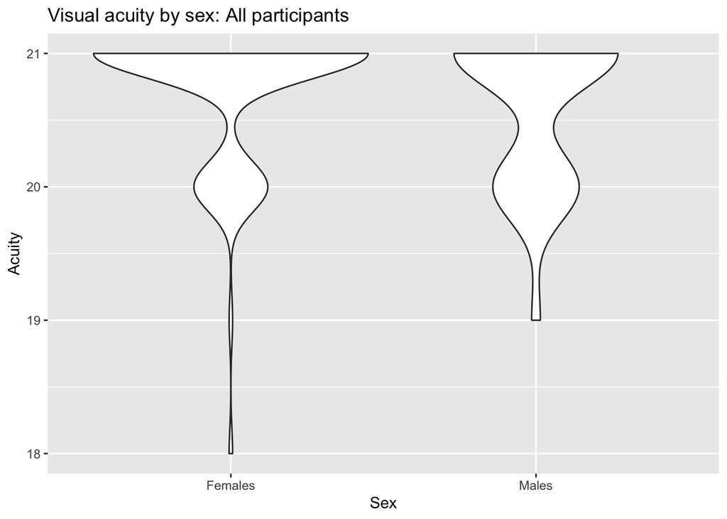

```r
df1 %>%
  ggplot(.) +
  aes(y = Acuity, x = Sex) +
  geom_violin() +
  ggtitle('Visual acuity by sex: All participants')
```

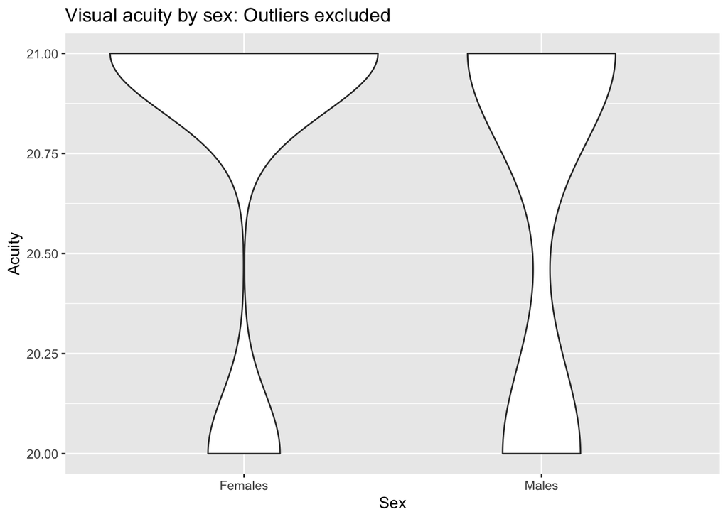

```r
df1[-a[['Acuity']],] %>%
  ggplot(.) +
  aes(y = Acuity, x = Sex) +
  geom_violin() +
  ggtitle('Visual acuity by sex: Outliers excluded')
```

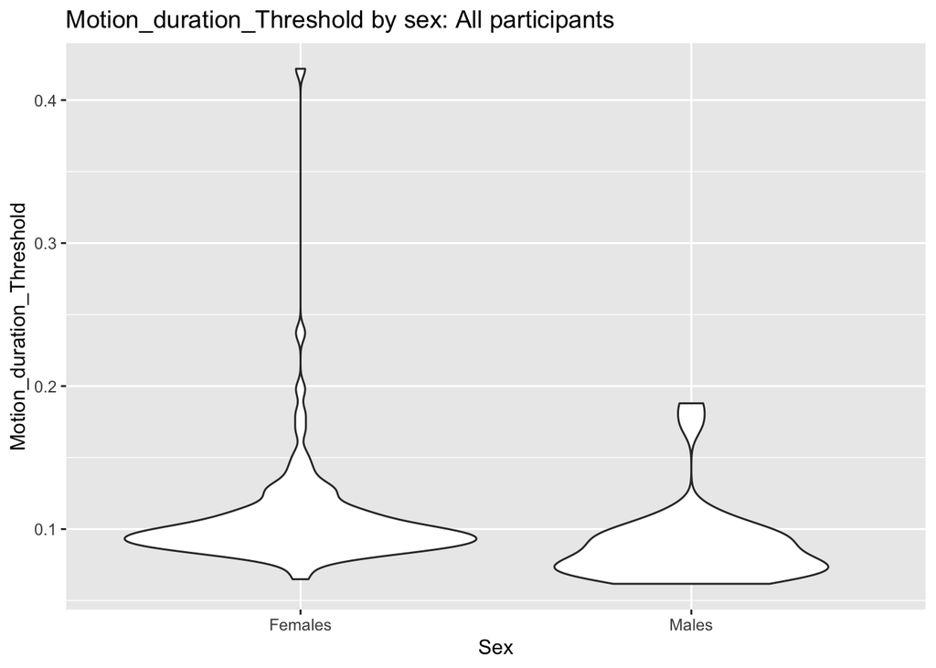

```r
df1 %>%
  ggplot(.) +
  aes(y = Motion_duration_Threshold, x = Sex) +
  geom_violin() +
  ggtitle('Motion_duration_Threshold by sex: All participants')
```

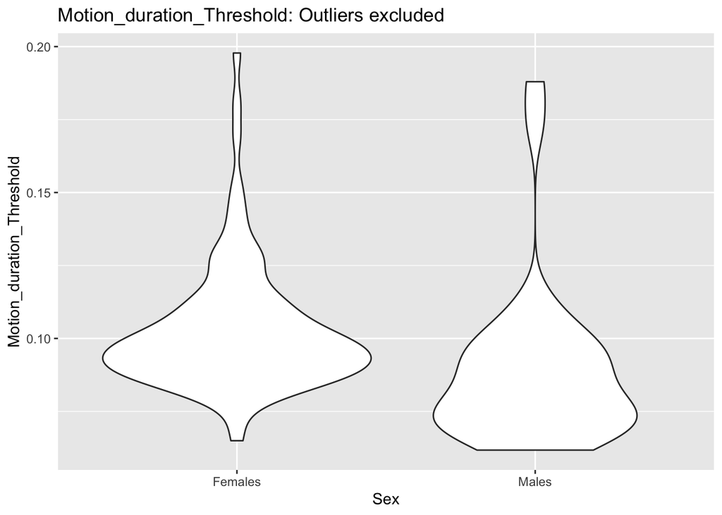

```r
df1[-a[['Motion_duration_Threshold']],] %>%
  ggplot(.) +
  aes(y = Motion_duration_Threshold, x = Sex) +
  geom_violin() +
  ggtitle('Motion_duration_Threshold: Outliers excluded')
```

```r
df1$Motion_duration_Threshold[a[['Motion_duration_Threshold']]]
```

```
## [1] 0.4219021 0.2371627
```

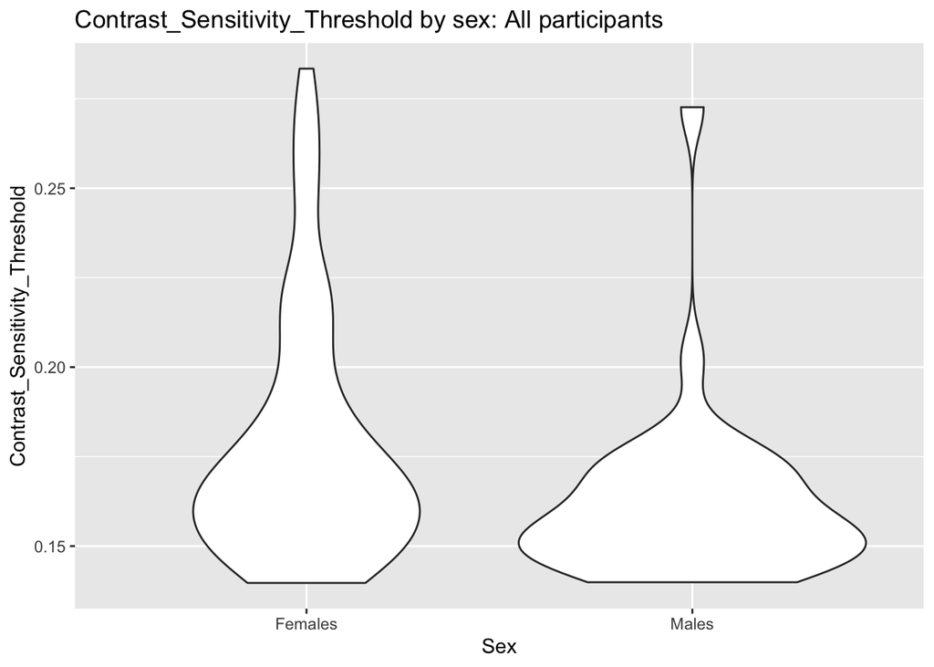

```r
df1 %>%
  ggplot(.) +
  aes(y = Contrast_Sensitivity_Threshold, x = Sex) +
  geom_violin() +
  ggtitle('Contrast_Sensitivity_Threshold by sex: All participants')
```

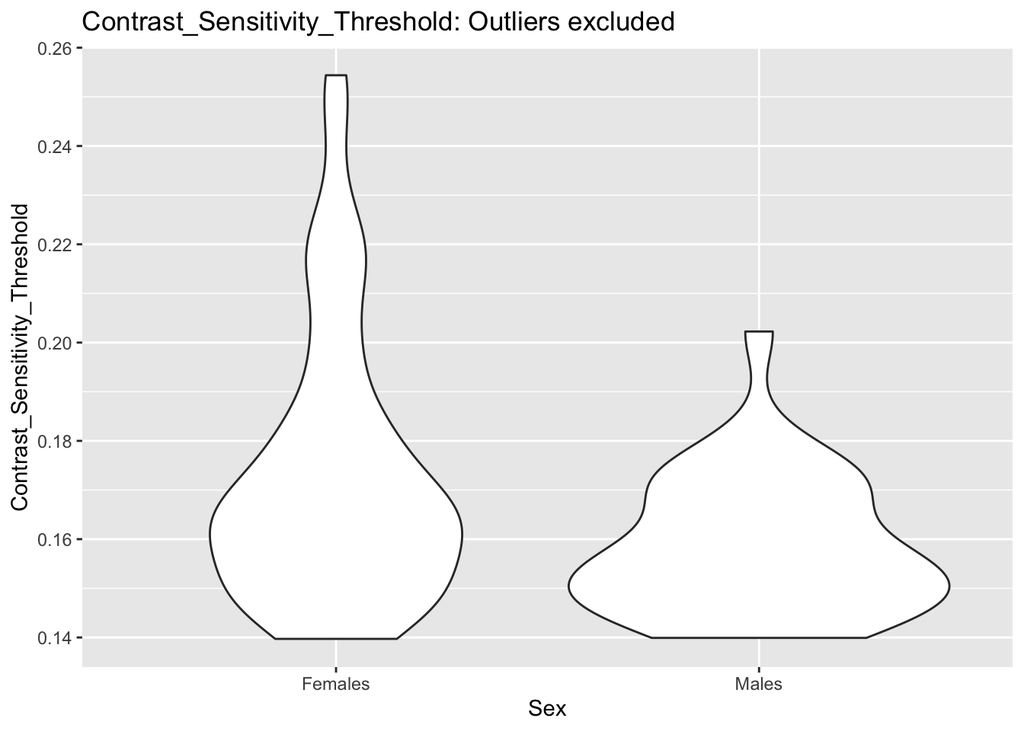

```r
df1[-a[['Contrast_Sensitivity_Threshold']],] %>%
  ggplot(.) +
  aes(y = Contrast_Sensitivity_Threshold, x = Sex) +
  geom_violin() +
  ggtitle('Contrast_Sensitivity_Threshold: Outliers excluded')
```

```r
df1$Contrast_Sensitivity_Threshold[a[['Contrast_Sensitivity_Threshold']]]
```

```
## [1] 0.2726373 0.2772047 0.2649820 0.2652312 0.2700757 0.2834012
```

```r
#boxplot(df1$Motion_duration_Threshold)
# check Flag_MRT
#
# df1$Contrast_Sensitivity_Threshold[a[[4]]] # 4 14 96
# #boxplot(df1$Contrast_Sensitivity_Threshold)
```

Exclude outliers

```r
df2 <- df1
df2$Contrast_Sensitivity_Threshold[a[['Contrast_Sensitivity_Threshold']]] <- NA
df2$Motion_duration_Threshold[a[['Motion_duration_Threshold']]] <- NA
```

## Check distributions

Preliminary tests to check assumptions underlying statistical tests.

Do the data follow a normal distributions?

Use Shapiro-Wilk normality test, `shapiro.test()` and look at the normality plot —> R function: `ggpubr::ggqqplot()`.

The Shapiro-Wilk test can be performed as follows: - Null hypothesis: the data are normally distributed - Alternative hypothesis: the data are not normally distributed

```r
# Shapiro-Wilk normality test
shapiro.test(df2$Motion_duration_Threshold) # => p <0.001
```

```
##
##  Shapiro-Wilk normality test
##
## data:  df2$Motion_duration_Threshold
## W = 0.85762, p-value = 1.17e-09
```

```r
shapiro.test(df2$Contrast_Sensitivity_Threshold) # => p <0.001
```

```
##
##  Shapiro-Wilk normality test
##
## data:  df2$Contrast_Sensitivity_Threshold
## W = 0.85837, p-value = 1.562e-09
```

```r
shapiro.test(df2$Vocabulary_scores) # => p <0.001
```

```
##
##  Shapiro-Wilk normality test
##
## data:  df2$Vocabulary_scores
## W = 0.97885, p-value = 0.03865
```

```r
shapiro.test(df2$Vocabulary_scores_cor_num) # => p <0.001
```

```
##
##  Shapiro-Wilk normality test
##
## data:  df2$Vocabulary_scores_cor_num
## W = 0.98748, p-value = 0.2785
```

```r
shapiro.test(df2$Mental_Rotation_scores) # => p <0.001
```

```
##
##  Shapiro-Wilk normality test
##
## data:  df2$Mental_Rotation_scores
## W = 0.97933, p-value = 0.04314
```

```r
shapiro.test(df2$Mental_Rotation_scores_both) # => p <0.001
```

```
##
##  Shapiro-Wilk normality test
##
## data:  df2$Mental_Rotation_scores_both
## W = 0.97483, p-value = 0.01545
```

```r
shapiro.test(df2$Feminine_hobbies) # => p >0.05
```

```
##
##  Shapiro-Wilk normality test
##
## data:  df2$Feminine_hobbies
## W = 0.98254, p-value = 0.09098
```

```r
shapiro.test(df2$Masculine_hobbies) # => p >0.05
```

```
##
##  Shapiro-Wilk normality test
##
## data:  df2$Masculine_hobbies
## W = 0.99399, p-value = 0.8568
```

We use a strict Bonferroni-style criterion of $p<0.0125$ in determining which variables to transform.

Let’s now describe the data.

```r
df2_f <- df2 %>%
  filter(Sex == "Females")

df2 %>%
  group_by(Sex) %>%
  Hmisc::describe(.)
```

```
## .
##
##  19  Variables      132  Observations
## --------------------------------------------------------------------------------
## Participant
##        n  missing distinct     Info     Mean      Gmd      .05      .10
##      132        0      132        1    317.3    117.9    107.5    114.1
##      .25      .50      .75      .90      .95
##    323.0    365.5    398.2    417.9    424.4
##
## lowest : 101 102 103 104 105, highest: 427 428 429 430 431
## --------------------------------------------------------------------------------
## Sex
##        n  missing distinct
##      132        0        2
##
## Value      Females   Males
## Frequency      102      30
## Proportion   0.773   0.227
## --------------------------------------------------------------------------------
## Race
##        n  missing distinct
##      131        1       13
##
## lowest : ,Black/African                       ,Black/African,Caucasian             ,Caucasian                           ,Caucasian,Hispanic/Latino           ,Caucasian,Pacific Islander
## highest: Asian,Black/African,Caucasian        Asian,Caucasian                      Asian,Caucasian,Hispanic/Latino      Asian,Caucasian,Prefer not to answer Asian,Hispanic/Latino
## --------------------------------------------------------------------------------
## Age
##        n  missing distinct     Info     Mean      Gmd
##      131        1        4    0.607    1.344   0.5348
##
## Value          1     2     3     4
## Frequency     95    30     3     3
## Proportion 0.725 0.229 0.023 0.023
## --------------------------------------------------------------------------------
## School_year
##        n  missing distinct     Info     Mean      Gmd
##      131        1        4    0.719     1.58   0.8489
##
## Value          1     2     3     4
```

[output cut: 121 more lines]

```
##      .25      .50      .75      .90      .95
##    3.211    3.526    3.868    4.053    4.211
##
## lowest : 2.315789 2.421053 2.473684 2.578947 2.684211
## highest: 4.105263 4.157895 4.263158 4.315789 4.421053
## --------------------------------------------------------------------------------
## Masculine_hobbies
##        n  missing distinct     Info     Mean      Gmd      .05      .10
##      131        1       46    0.999    2.954   0.5959    2.048    2.286
##      .25      .50      .75      .90      .95
##    2.643    2.952    3.286    3.619    3.810
##
## lowest : 1.714286 1.761905 1.952381 2.000000 2.047619
## highest: 3.904762 3.952381 4.047619 4.285714 4.428571
## --------------------------------------------------------------------------------
```

## T-test: Comparison between Sexes

Here is our pre-registered description of how we planned to compare sex differences:

> To examine sex differences, one-tailed t tests will be conducted to compare men and women on 2 visual perception thresholds, spatial ability, and masculine hobbies. We will use verbal ability as our control variable. We set a family-wise Type I error rate at $\alpha$=0.05. Because there are four dependent variables hypothesized to show sex differences, the critical p value for each sex comparison is 0.0125 after Bonferroni correction. Our goal is to obtain .8 power to detect a medium effect size of .5 (Cohen’s $d$) at the $p$ value of .0125 in the one-tailed t tests. Unequal sample sizes of the two sexes may be collected in this study. The minimum effect size of .50 can be obtained by at least 45 male participants out of a total sample size of 300 (see the R-code for power analysis at WRONG URL! shorturl.at/nDHLV). The minimum detectable effect size decreases when male and female sample sizes differ less, but to simply our $t$ tests, we set the effect sizes at .5.

Since the motion duration and contrast sensitivity theshold scores are not normally distributed, we (log) transform them (see below)

### Vocabulary

```r
advoc_total_t <-
  t.test(
    Vocabulary_scores ~ Sex,
    data = df2,
    var.equal = TRUE,
    alternative = "less"
  )
advoc_total_t
```

```
##
##  Two Sample t-test
##
## data:  Vocabulary_scores by Sex
## t = -0.74845, df = 129, p-value = 0.2278
## alternative hypothesis: true difference in means is less than 0
## 95 percent confidence interval:
##       -Inf 0.9111823
## sample estimates:
## mean in group Females   mean in group Males
##              9.165842              9.916667
```

```r
advoc_cor_t <-
  t.test(
    Vocabulary_scores_cor_num ~ Sex,
    data = df2,
    var.equal = TRUE,
    alternative = "less"
  )
advoc_cor_t
```

```
##
##  Two Sample t-test
##
## data:  Vocabulary_scores_cor_num by Sex
## t = -0.66033, df = 129, p-value = 0.2551
## alternative hypothesis: true difference in means is less than 0
## 95 percent confidence interval:
##       -Inf 0.8386487
## sample estimates:
## mean in group Females   mean in group Males
##              13.91089              14.46667
```

Vocabulary is a control variable in the study. As we predicted, the vocabulary score did not differ between males and females.

### Mental rotation

```r
t.test(
  Mental_Rotation_scores ~ Sex,
  data = df2,
  var.equal = TRUE,
  alternative = "less"
) #Hypothesized
```

```
##
##  Two Sample t-test
##
## data:  Mental_Rotation_scores by Sex
## t = -2.7478, df = 129, p-value = 0.003429
## alternative hypothesis: true difference in means is less than 0
## 95 percent confidence interval:
##       -Inf -1.373374
## sample estimates:
## mean in group Females   mean in group Males
##              26.20792              29.66667
```

```r
t.test(
  Mental_Rotation_scores_both ~ Sex,
  data = df2,
  var.equal = TRUE,
  alternative = "less"
) #Hypothesized
```

```
##
##  Two Sample t-test
##
## data:  Mental_Rotation_scores_both by Sex
## t = -2.9895, df = 129, p-value = 0.001673
## alternative hypothesis: true difference in means is less than 0
## 95 percent confidence interval:
##       -Inf -1.274324
## sample estimates:
## mean in group Females   mean in group Males
##              8.841584             11.700000
```

Sex differences in mental rotation test was found in our study. Males had significantly more correct answers in the mental rotation task than females. This was also the case where we analyzed just the mental rotation items where both correct responses were selected.

### Feminine hobbies

```r
t.test(
  Feminine_hobbies ~ Sex,
  data = df2,
  var.equal = TRUE,
  alternative = "greater"
)
```

```
##
##  Two Sample t-test
##
## data:  Feminine_hobbies by Sex
## t = 4.8717, df = 129, p-value = 1.592e-06
## alternative hypothesis: true difference in means is greater than 0
## 95 percent confidence interval:
##  0.2887051       Inf
## sample estimates:
## mean in group Females   mean in group Males
##              3.602397              3.164912
```

Although we did not include female-type hobbies in our preregistration, we found that females had higher scores in female-typed hobbies than males.

### Masculine hobbies

```r
t.test(
  Masculine_hobbies ~ Sex,
  data = df2,
  var.equal = TRUE,
  alternative = "less"
) #Hypothesized
```

```
##
##  Two Sample t-test
##
## data:  Masculine_hobbies by Sex
## t = -7.422, df = 129, p-value = 6.896e-12
## alternative hypothesis: true difference in means is less than 0
## 95 percent confidence interval:
##        -Inf -0.5307975
## sample estimates:
## mean in group Females   mean in group Males
##              2.797619              3.480952
```

As predicted, we found males have higher scores in male-typed hobbies than females.

## Transformation

> If necessary, we will transform the psychophysical thresholds to make the distributions symmetric and appropriate for parametric analyses.

For the distributions which are not normal (particularly for distributions that are right skewed), we will try the log transformation.

### log(Motion duration threshold)

```r
shapiro.test(log(df2$Motion_duration_Threshold))
```

```
##
##  Shapiro-Wilk normality test
##
## data:  log(df2$Motion_duration_Threshold)
## W = 0.9497, p-value = 0.000139
```

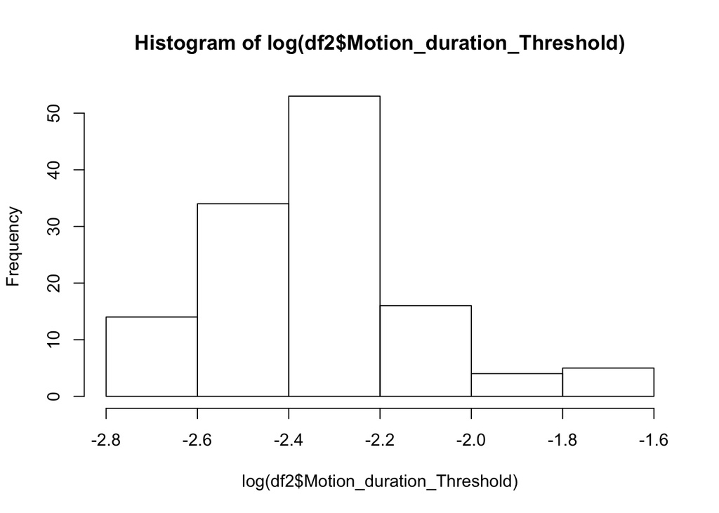

```r
hist(log(df2$Motion_duration_Threshold))
```

Even after the log transformation, `Motion_duration_Threshold` remains non-normal, but it is more symmetric.

```r
mdt_tt <-
  t.test(
    log(Motion_duration_Threshold) ~ Sex,
    data = df2,
    var.equal = TRUE,
    alternative = "greater"
  ) #Hypothesized
mdt_tt
```

```
##
##  Two Sample t-test
##
## data:  log(Motion_duration_Threshold) by Sex
## t = 3.7359, df = 124, p-value = 0.000142
## alternative hypothesis: true difference in means is greater than 0
## 95 percent confidence interval:
##  0.089656      Inf
## sample estimates:
## mean in group Females   mean in group Males
##             -2.293820             -2.454955
```

We found there are sex differences in log(`Motion_duration_Threshold`). Males took significantly shorter time to detect the direction of the motion than females.

### log(Contrast_Sensitivity_Threshold)

```r
shapiro.test(log(df2$Contrast_Sensitivity_Threshold))
```

```
##
##  Shapiro-Wilk normality test
##
## data:  log(df2$Contrast_Sensitivity_Threshold)
## W = 0.90212, p-value = 1.739e-07
```

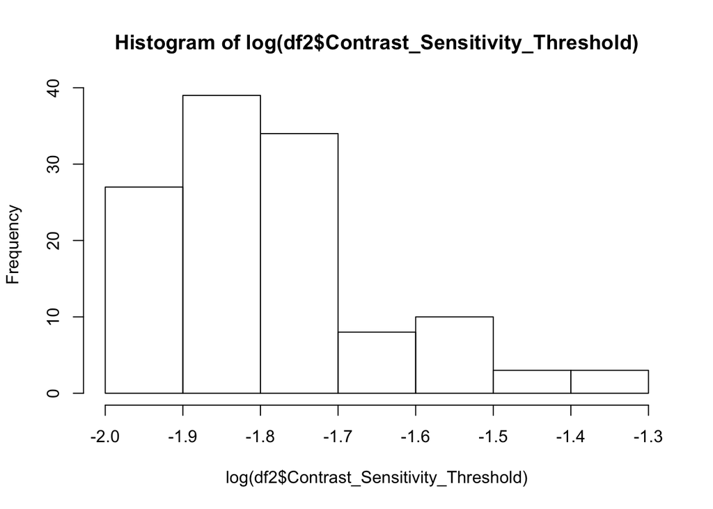

```r
hist(log(df2$Contrast_Sensitivity_Threshold))
```

`Contrast_Sensitivity_Threshold` remains non-normal even after transformation.

```r
t.test(
  log(Contrast_Sensitivity_Threshold) ~ Sex,
  data = df2,
  var.equal = TRUE,
  alternative = "greater"
) #Hypothesized
```

```
##
##  Two Sample t-test
##
## data:  log(Contrast_Sensitivity_Threshold) by Sex
## t = 2.8161, df = 122, p-value = 0.002835
## alternative hypothesis: true difference in means is greater than 0
## 95 percent confidence interval:
##  0.03373729        Inf
## sample estimates:
## mean in group Females   mean in group Males
##             -1.764491             -1.846487
```

Log transformed `Contrast_Sensitivity_Threshold` data show the predicted sex differences. Males detect the stimuli with lower contrast than females.

## Power analysis

```r
t_power <-
  pwr.t2n.test(
    n1 = 102 ,
    n2 = 30 ,
    d = NULL,
    sig.level = 0.0125,
    power = 0.8,
    alternative = "greater"
  )
t_power
```

```
##
##      t test power calculation
##
##              n1 = 102
##              n2 = 30
##               d = 0.6465883
##       sig.level = 0.0125
##           power = 0.8
##     alternative = greater
```

We need $|d|>0.65$ for a one-sided t test with $p$ value of lower than 0.0125 and with power of 0.8.

## Correlation within Sex

> To examine how individual differences of visual perception measures are associated with other tasks, we will use correlations within sex. The lower visual perception threshold is, the higher perceptual sensitivity this individual has. In both sexes, we expect to find negative correlations between visual perception measures and spatial ability and masculine hobbies, but no significant correlation with verbal ability. There are four planned correlations (two visual perception tasks × two cognitive tasks) within sex, for a total of eight. This project is a novel study that has not to our knowledge been conducted previously. So we have consciously decided to maintain strict control of Type II error, in order to have enough statistical power to detect a small correlation effect sizes (r=0.20) within the constraints of sample size. This decision to maximize the power (.80) leads to a trade-off between Type I and Type II error. We plan to conduct eight separate one-tailed correlation tests with Type I error at 0.05 and no Bonferroni correction. With a critical p value of .05, around 150 participants are required for each group to detect an effect size of 0.20 at an obtained power of 0.8 with a one-tailed correlation test.

### Overall

```r
meets_criterion <- function(observed_p, criterion_p = .05/4) {
  if (observed_p <= criterion_p) {
    "meets"
  } else {
    "does not meet"
  }
}
```

Because our preregistration envisioned a much larger total sample, we have chosen to report the overall correlations, combining males and females.

We select the variables for our correlation analysis, and make sure to log transform the threshold measures.

```r
df_corr <- df2 %>%
  dplyr::mutate(., Motion_duration_Threshold = log(Motion_duration_Threshold),
                Contrast_Sensitivity_Threshold = log(Contrast_Sensitivity_Threshold)) %>%
  dplyr::select(., Sex,
                Motion_duration_Threshold,
                Contrast_Sensitivity_Threshold,
                Vocabulary_scores,
                Vocabulary_scores_cor_num,
                Mental_Rotation_scores,
                Mental_Rotation_scores_both,
                Feminine_hobbies,
                Masculine_hobbies)
```

Then, we drop incomplete cases.

```r
df_complete <- df_corr[stats::complete.cases(df_corr),]
```

This gives us $n=$ 118 complete cases.

We select just the numeric scores to calculate the correlation table.

```r
df_complete_num <- df_complete %>%
  dplyr::select(., -Sex)
```

```r
corr_all <- Hmisc::rcorr(as.matrix(df_complete_num), type = c("pearson"))
```

#### Coefficients

```r
corr_all$r
```

```
##                                Motion_duration_Threshold
## Motion_duration_Threshold                      1.0000000
## Contrast_Sensitivity_Threshold                 0.2295038
## Vocabulary_scores                             -0.1976843
## Vocabulary_scores_cor_num                     -0.1577094
## Mental_Rotation_scores                        -0.1923005
## Mental_Rotation_scores_both                   -0.2120844
## Feminine_hobbies                               0.2767336
## Masculine_hobbies                             -0.1499468
##                                Contrast_Sensitivity_Threshold Vocabulary_scores
## Motion_duration_Threshold                          0.22950378       -0.19768429
## Contrast_Sensitivity_Threshold                     1.00000000       -0.08827076
## Vocabulary_scores                                 -0.08827076        1.00000000
## Vocabulary_scores_cor_num                         -0.04626488        0.95310781
## Mental_Rotation_scores                            -0.26260756        0.02273680
## Mental_Rotation_scores_both                       -0.22335920        0.08456938
## Feminine_hobbies                                   0.20391783       -0.12625375
## Masculine_hobbies                                 -0.15312043        0.05694144
##                                Vocabulary_scores_cor_num Mental_Rotation_scores
## Motion_duration_Threshold                    -0.15770940            -0.19230052
## Contrast_Sensitivity_Threshold               -0.04626488            -0.26260756
## Vocabulary_scores                             0.95310781             0.02273680
## Vocabulary_scores_cor_num                     1.00000000            -0.02480670
## Mental_Rotation_scores                       -0.02480670             1.00000000
## Mental_Rotation_scores_both                   0.02068100             0.93560009
## Feminine_hobbies                             -0.12647684            -0.28642598
## Masculine_hobbies                             0.08712102             0.07040407
##                                Mental_Rotation_scores_both Feminine_hobbies
## Motion_duration_Threshold                      -0.21208437        0.2767336
## Contrast_Sensitivity_Threshold                 -0.22335920        0.2039178
## Vocabulary_scores                               0.08456938       -0.1262538
## Vocabulary_scores_cor_num                       0.02068100       -0.1264768
## Mental_Rotation_scores                          0.93560009       -0.2864260
## Mental_Rotation_scores_both                     1.00000000       -0.2433610
## Feminine_hobbies                               -0.24336098        1.0000000
## Masculine_hobbies                               0.08277694        0.1469108
##                                Masculine_hobbies
## Motion_duration_Threshold            -0.14994681
## Contrast_Sensitivity_Threshold       -0.15312043
## Vocabulary_scores                     0.05694144
## Vocabulary_scores_cor_num             0.08712102
## Mental_Rotation_scores                0.07040407
## Mental_Rotation_scores_both           0.08277694
## Feminine_hobbies                      0.14691084
## Masculine_hobbies                     1.00000000
```

#### P-values

```r
corr_all$P
```

```
##                                Motion_duration_Threshold
## Motion_duration_Threshold                             NA
## Contrast_Sensitivity_Threshold                0.01242024
## Vocabulary_scores                             0.03189179
## Vocabulary_scores_cor_num                     0.08807946
## Mental_Rotation_scores                        0.03696105
## Mental_Rotation_scores_both                   0.02113328
## Feminine_hobbies                              0.00241678
## Masculine_hobbies                             0.10508698
##                                Contrast_Sensitivity_Threshold Vocabulary_scores
## Motion_duration_Threshold                         0.012420237        0.03189179
## Contrast_Sensitivity_Threshold                             NA        0.34185033
## Vocabulary_scores                                 0.341850328                NA
## Vocabulary_scores_cor_num                         0.618849299        0.00000000
## Mental_Rotation_scores                            0.004067451        0.80693090
## Mental_Rotation_scores_both                       0.015045892        0.36255266
## Feminine_hobbies                                  0.026769584        0.17309522
## Masculine_hobbies                                 0.097846556        0.54023674
##                                Vocabulary_scores_cor_num Mental_Rotation_scores
## Motion_duration_Threshold                     0.08807946            0.036961046
## Contrast_Sensitivity_Threshold                0.61884930            0.004067451
## Vocabulary_scores                             0.00000000            0.806930899
## Vocabulary_scores_cor_num                             NA            0.789744673
## Mental_Rotation_scores                        0.78974467                     NA
## Mental_Rotation_scores_both                   0.82409170            0.000000000
## Feminine_hobbies                              0.17233097            0.001664191
## Masculine_hobbies                             0.34819955            0.448700373
##                                Mental_Rotation_scores_both Feminine_hobbies
## Motion_duration_Threshold                       0.02113328      0.002416780
## Contrast_Sensitivity_Threshold                  0.01504589      0.026769584
## Vocabulary_scores                               0.36255266      0.173095216
## Vocabulary_scores_cor_num                       0.82409170      0.172330969
## Mental_Rotation_scores                          0.00000000      0.001664191
## Mental_Rotation_scores_both                             NA      0.007919490
## Feminine_hobbies                                0.00791949               NA
## Masculine_hobbies                               0.37285070      0.112399856
##                                Masculine_hobbies
## Motion_duration_Threshold             0.10508698
## Contrast_Sensitivity_Threshold        0.09784656
## Vocabulary_scores                     0.54023674
## Vocabulary_scores_cor_num             0.34819955
## Mental_Rotation_scores                0.44870037
## Mental_Rotation_scores_both           0.37285070
## Feminine_hobbies                      0.11239986
## Masculine_hobbies                             NA
```

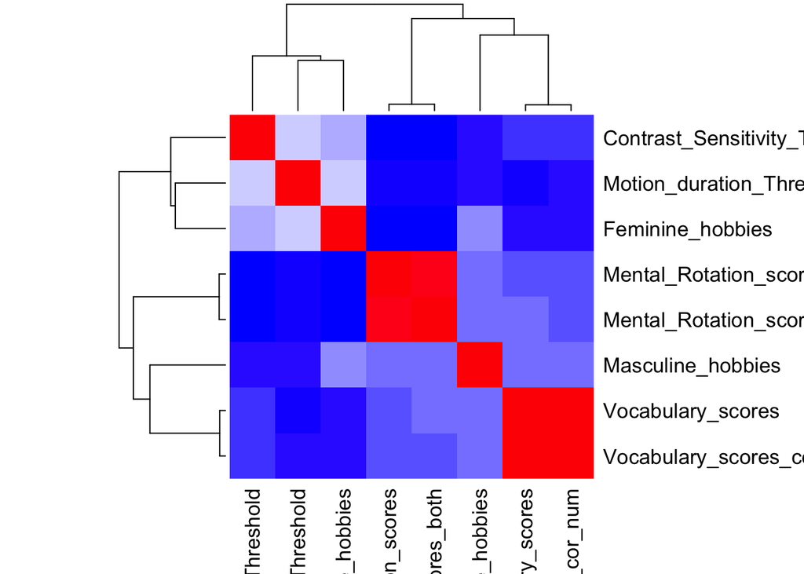

```r
# Get some colors
col <- colorRampPalette(c("blue", "white", "red"))(20)
heatmap(x = corr_all$r, col = col, symm = TRUE)
```

### Females

Select the females and focus on the numeric scores.

```r
df_complete_F <- df_complete %>%
  dplyr::filter(., Sex == 'Females')

df_corr_F <- df_complete_F %>%
  dplyr::select(., -Sex)

corr_F <- Hmisc::rcorr(as.matrix(df_corr_F), type = c("pearson"))
```

#### Coefficients

```r
corr_F$r
```

```
##                                Motion_duration_Threshold
## Motion_duration_Threshold                     1.00000000
## Contrast_Sensitivity_Threshold                0.19841063
## Vocabulary_scores                            -0.19503526
## Vocabulary_scores_cor_num                    -0.18627682
## Mental_Rotation_scores                       -0.28353803
## Mental_Rotation_scores_both                  -0.29518756
## Feminine_hobbies                              0.19685114
## Masculine_hobbies                             0.03079113
##                                Contrast_Sensitivity_Threshold Vocabulary_scores
## Motion_duration_Threshold                          0.19841063       -0.19503526
## Contrast_Sensitivity_Threshold                     1.00000000       -0.06224564
## Vocabulary_scores                                 -0.06224564        1.00000000
## Vocabulary_scores_cor_num                         -0.01167467        0.94819069
## Mental_Rotation_scores                            -0.24889252        0.08824885
## Mental_Rotation_scores_both                       -0.20554946        0.16190505
## Feminine_hobbies                                   0.09815024       -0.08309512
## Masculine_hobbies                                 -0.06375185        0.02673513
##                                Vocabulary_scores_cor_num Mental_Rotation_scores
## Motion_duration_Threshold                    -0.18627682            -0.28353803
## Contrast_Sensitivity_Threshold               -0.01167467            -0.24889252
## Vocabulary_scores                             0.94819069             0.08824885
## Vocabulary_scores_cor_num                     1.00000000             0.04335083
## Mental_Rotation_scores                        0.04335083             1.00000000
## Mental_Rotation_scores_both                   0.09972704             0.92118598
## Feminine_hobbies                             -0.06841209            -0.34014442
## Masculine_hobbies                             0.07733475            -0.08023468
##                                Mental_Rotation_scores_both Feminine_hobbies
## Motion_duration_Threshold                      -0.29518756       0.19685114
## Contrast_Sensitivity_Threshold                 -0.20554946       0.09815024
## Vocabulary_scores                               0.16190505      -0.08309512
## Vocabulary_scores_cor_num                       0.09972704      -0.06841209
## Mental_Rotation_scores                          0.92118598      -0.34014442
## Mental_Rotation_scores_both                     1.00000000      -0.30621746
## Feminine_hobbies                               -0.30621746       1.00000000
## Masculine_hobbies                              -0.09986451       0.48011035
##                                Masculine_hobbies
## Motion_duration_Threshold             0.03079113
## Contrast_Sensitivity_Threshold       -0.06375185
## Vocabulary_scores                     0.02673513
## Vocabulary_scores_cor_num             0.07733475
## Mental_Rotation_scores               -0.08023468
## Mental_Rotation_scores_both          -0.09986451
## Feminine_hobbies                      0.48011035
## Masculine_hobbies                     1.00000000
```

#### P values

```r
corr_F$P
```

```
##                                Motion_duration_Threshold
## Motion_duration_Threshold                             NA
## Contrast_Sensitivity_Threshold               0.062333211
## Vocabulary_scores                            0.067014036
## Vocabulary_scores_cor_num                    0.080494839
## Mental_Rotation_scores                       0.007090267
## Mental_Rotation_scores_both                  0.004980480
## Feminine_hobbies                             0.064461717
## Masculine_hobbies                            0.774537719
##                                Contrast_Sensitivity_Threshold Vocabulary_scores
## Motion_duration_Threshold                          0.06233321        0.06701404
## Contrast_Sensitivity_Threshold                             NA        0.56226180
## Vocabulary_scores                                  0.56226180                NA
## Vocabulary_scores_cor_num                          0.91353139        0.00000000
## Mental_Rotation_scores                             0.01867302        0.41086351
## Mental_Rotation_scores_both                        0.05330704        0.12956057
## Feminine_hobbies                                   0.36015497        0.43882666
## Masculine_hobbies                                  0.55282265        0.80359469
##                                Vocabulary_scores_cor_num Mental_Rotation_scores
## Motion_duration_Threshold                     0.08049484            0.007090267
## Contrast_Sensitivity_Threshold                0.91353139            0.018673016
## Vocabulary_scores                             0.00000000            0.410863515
## Vocabulary_scores_cor_num                             NA            0.686669307
## Mental_Rotation_scores                        0.68666931                     NA
## Mental_Rotation_scores_both                   0.35245200            0.000000000
## Feminine_hobbies                              0.52411077            0.001108726
## Masculine_hobbies                             0.47131522            0.454799070
##                                Mental_Rotation_scores_both Feminine_hobbies
## Motion_duration_Threshold                      0.004980480     6.446172e-02
## Contrast_Sensitivity_Threshold                 0.053307036     3.601550e-01
## Vocabulary_scores                              0.129560567     4.388267e-01
## Vocabulary_scores_cor_num                      0.352452002     5.241108e-01
## Mental_Rotation_scores                         0.000000000     1.108726e-03
## Mental_Rotation_scores_both                             NA     3.517592e-03
## Feminine_hobbies                               0.003517592               NA
## Masculine_hobbies                              0.351785335     1.925334e-06
##                                Masculine_hobbies
## Motion_duration_Threshold           7.745377e-01
## Contrast_Sensitivity_Threshold      5.528226e-01
## Vocabulary_scores                   8.035947e-01
## Vocabulary_scores_cor_num           4.713152e-01
## Mental_Rotation_scores              4.547991e-01
## Mental_Rotation_scores_both         3.517853e-01
## Feminine_hobbies                    1.925334e-06
## Masculine_hobbies                             NA
```

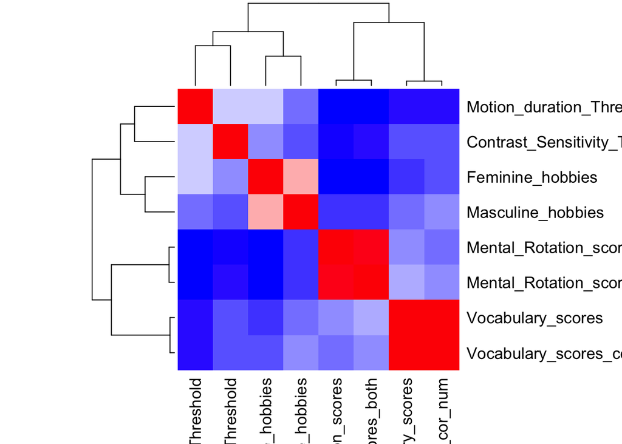

```r
# Get some colors
col <- colorRampPalette(c("blue", "white", "red"))(20)
heatmap(x = corr_F$r, col = col, symm = TRUE)
```